# What the Roll Call Record Contains

Every vote since 1789, and no note of what most of them were about

Democracy’s Data

Last updated September 13, 2026 at 10:53a EDT

Congress keeps a record of itself. Every time either chamber takes a recorded vote — a *roll call*, so called because the clerk once called each member’s name and noted the answer — the chamber writes down how every member voted, by name, and has done so since 1789. Nobody made this record for researchers. The chambers keep it because the Constitution tells each one to keep a Journal of its proceedings, and because a chamber has to know whether the bill passed.[^1]

An election return is complete: every ballot counted lands in some total. A roll call looks equally official and is a different kind of object, because **the Constitution does not require one**. Article I, Section 5 provides that the yeas and nays are entered on the Journal “at the Desire of one fifth of those Present.” A recorded vote happens when somebody wants one. Everything else leaves no record of who was on which side: voice votes, in which members call out together and only the louder side is noted; unanimous consent, in which a measure goes through because nobody objects; and the great bulk of legislative business.

So the roll call record is a sample of decisions, and the sampling was done by the people being recorded. That is the first thing to know about it. The second is that for most of American history, the record does not say what the vote was about.

Hold on to what the record is, before this chapter turns to what it lacks. Nothing else in this book is like it. Election returns are anonymous by constitutional design. Surveys ask a sample and get self-reports. Voter files record whether you voted and never how.

This is the only source where the behaviour of named individuals is recorded completely, by law, over two centuries. That is why the entire study of legislative coalitions, party discipline and polarization rests on it.

## Where the data comes from, and what it is for

The chambers produce the raw record and always have. The Clerk of the House and the Secretary of the Senate enter each roll call in the Journal. Since 1973 the House has taken most recorded votes by electronic machine, which multiplied how many it takes.[^2] But no government office publishes the whole record as one file. The dataset nearly everyone uses is Voteview, assembled at UCLA by the political scientists Keith Poole, Howard Rosenthal, Jeffrey Lewis and their colleagues, and downloadable by anyone at https://voteview.com/data. They keyed the early Journals by hand and take the chambers’ own published votes for the rest.

**Who is in it, and how they got there.** Every member of the House and Senate who ever answered a recorded vote, from the 1st Congress on. They got there by winning an election, being present, and voting when the yeas and nays were called. Nobody in the file consented to be studied, and nobody could opt out: the vote *is* the record. What is not in it is everything the chambers decided without calling names, which is most of what they decide.

**Who it was made for.** The chamber itself, twice over. The Journal settles whether a measure passed, which is bookkeeping. And the recorded vote is an accountability device. The point of demanding the yeas and nays is to put colleagues on the record, so that voters, party leaders and opponents can read the record back to them. The file was built to assign responsibility, not to describe ideology.

**What it costs to get.** Nothing. Voteview hands you the whole record as plain spreadsheet files, with no account to open, from the address above. The cost sits elsewhere and was paid long ago: decades of scholars transcribing two centuries of Journals, reconciling names, and keeping the series running as each new Congress votes. You inherit that work along with its judgment calls.

**What has already been done to it.** The record has been digitised, standardised and annotated. Member identifiers were made consistent across two centuries so that one person keeps one number through renames and party switches. Each roll call carries its date, chamber, totals, and, where anybody recorded it, the question being voted on. And each carries midpoints from NOMINATE, the method that places every member on a left–right line according to how often they vote with and against each other, which is to say the file already contains manufactured numbers sitting beside the measured ones.

## How the record is published

Voteview publishes the record as three flat files, refreshed as Congress votes. A members file holds one row per member per Congress. A roll-call file holds one row per recorded vote, with its totals and question. And a votes file holds the full grid: **one row per member per roll call**, which is the shape the complete record actually has. To know how one person voted on one question, you need that grid, and it is the raw material every measure of legislative behaviour is computed from.

This chapter reads the roll-call file, `HSall_rollcalls.csv`: 113,512 recorded votes, House and Senate, from the 1st Congress to the 119th. The chambers also publish their own modern votes: the Clerk of the House at https://clerk.house.gov/Votes and the Senate at https://www.senate.gov/legislative/votes_new.htm. Voteview reconciles those into the same series that the hand-keyed Journals begin.

Here is one row of that file, read field by field: the House vote of 21 March 2010 that sent the Affordable Care Act to the President.

| Field | Value |
| --- | --- |
| congress | 111 |
| chamber | House |
| rollnumber | 1150 |
| date | 2010-03-21 |
| yea_count | 219 |
| nay_count | 212 |
| vote_result | Passed |
| vote_question | On Motion to Concur in Senate Amendments |
| vote_desc | Patient Protection and Affordable Care Act |
| bill_number | HR3590 |

`congress` and `chamber` say which House; `rollnumber` is the vote’s place in that Congress’s sequence; `date` is the day. `yea_count` and `nay_count` are the totals, 219 to 212, and `vote_result` says the motion passed. `vote_question` is the parliamentary form the vote took — here a motion to accept the Senate’s amendments, which is how the bill cleared the House, not a vote “on passage” — and `vote_desc` is the only field that says what it was about. What the row does not contain is any member’s name. Those sit in the votes file, one row per member per roll call: 431 rows for this one vote, each carrying a member’s identifier and a code for yea, nay, or something else.

## A count of roll calls measures the recording rule

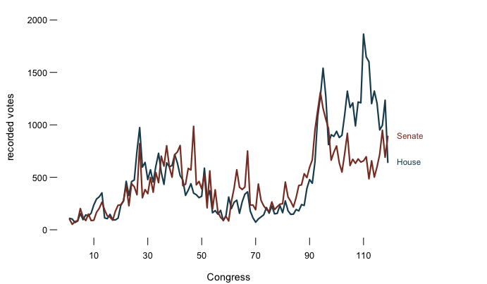

**Figure 1. Recorded votes per Congress, 1789 to the present.** A line over two centuries fits this question because the claim is about *when the level changed*, not about any one Congress — and the change is a cliff, not a drift. Hover for both chambers at any Congress.

The shape of Figure 1 is worth pausing on, because it is easy to read as a story about Congress and is mostly a story about recording. The jump after the 91st Congress follows procedural changes that made recorded votes easier to obtain in the House, including the electronic voting system. Members did not suddenly start deciding more things. More of what they decided started leaving a trace.

**A count of roll calls is a measure of the recording rule, not of legislative activity.** Any series built on “votes per Congress” inherits that.

## The file does not say what most votes were about

Voteview’s roll call file has a field for the question being voted on. Here is how often it is filled in.

| Congresses | Years | Roll calls | Question recorded |
| --- | --- | --- | --- |
| 1-50 | 1789-1888 | 37,002 | 0.0% |
| 51-80 | 1889-1948 | 15,173 | 0.0% |
| 81-100 | 1949-1988 | 25,763 | 0.0% |
| 101-110 | 1989-2008 | 18,578 | 98.0% |
| 111-119 | 2009-2026 | 16,996 | 100.0% |

## The scores are manufactured from this record

The most quoted numbers about Congress are that it is polarized, that a member is a moderate, that the parties have moved apart. None of them appears in any clerk’s record. They are ideology scores, and every one of them is manufactured from the file this chapter describes. A scaling method reads the grid of who voted with whom, and places members on a line so that members who agree often sit close together. DW-NOMINATE is the standard one, and the DW-NOMINATE chapter owns the method: what the model assumes, what the score means, and what happens when the famous polarization chart is put to a test.

What matters here is what the raw material permits. Scaling works from the pattern of agreement and disagreement alone. It does not read the bills, and for most of the series **there is nothing to read** — the question field is empty. That is not a criticism of the method; it is a description of what the method had available. But it means a sentence like “this member voted conservatively in the 1870s” is a statement about who they voted *with*, and cannot be a statement about what they voted *for*.

## The courts keep a parallel record

The Supreme Court produces the same kind of data, one flight up. Every decision records how each of nine named justices voted, the Court has sat since 1789, and the Supreme Court Database, maintained at Washington University in St. Louis and downloadable at http://scdb.wustl.edu/data.php, holds the modern record case by case, justice by justice. It is the judiciary’s roll call: complete about behaviour, official in origin, and assembled into a research file by scholars rather than by the government.

The same manufacture runs on it. Ideal-point scores for justices — a position on a line estimated for each justice, of which Martin-Quinn scores are the best known[^3] — are built from patterns of agreement in exactly the way NOMINATE is built from roll calls. The Supreme Court chapter constructs one from nothing but agreement, so you can watch the machinery work on a court small enough to check by hand. And the oral argument chapter reads the Court’s other record, the transcript, where the hard decision is what to count at all.

## Not every recorded vote is the same kind of event

Where the question *is* recorded, this is what it is.

| Question | Roll calls | Share of all roll calls |
| --- | --- | --- |
| On Agreeing to the Amendment | 7,296 | 6.4% |
| On the Amendment | 3,602 | 3.2% |
| On Passage | 2,479 | 2.2% |
| On Agreeing to the Resolution | 2,103 | 1.9% |
| On the Cloture Motion | 2,102 | 1.9% |
| On the Nomination | 1,926 | 1.7% |
| On the Motion to Table | 1,710 | 1.5% |
| On Motion to Suspend the Rules and Pass | 1,549 | 1.4% |
| On Motion to Suspend the Rules and Pass, as Amended | 1,463 | 1.3% |
| On Ordering the Previous Question | 1,281 | 1.1% |

**Final passage, the vote on whether a bill becomes the chamber’s decision, is 2.2% of all roll calls.** The rest are amendments, procedural motions, cloture (the Senate’s vote to end debate), tabling (setting a measure aside, usually for good), nominations, and motions to suspend the rules (the House’s fast track for measures expected to pass by a wide margin).

These are not interchangeable. A member may vote against a bill on final passage having voted for every amendment that shaped it. Or vote to end debate on a bill they intend to oppose. Or vote to table a measure they support, because the timing is wrong. A procedural vote can be the substantive one, as cloture in the Senate frequently is. And a substantive vote can be a free vote whose outcome was never in doubt.

A method that treats all 113,512 alike is making an assumption. It is often a reasonable one, and it is never a fact.

## A worked example: how much of the record carries information

Here is one question the file can answer about itself, and it is the question that decides how far the manufactured scores can reach: how lopsided are the recorded votes? A 430–0 vote is a real event with real meaning in the chamber. It tells you nothing whatever about which members differ from which others, and that is the only thing a scaling method can use. So band every roll call by the size of its losing side and count. The March 2010 vote above had 212 members on the losing side out of 431 voting, a losing share of 49.2%, which puts it in the bottom band below, among the close votes; a vote of 400 to 20 would have a losing share of 4.8% and land in the second band.

| Margin | Roll calls | Share |
| --- | --- | --- |
| Unanimous – nobody on the losing side | 6,520 | 5.7% |
| Losing side under 10% | 12,644 | 11.1% |
| Losing side 10-20% | 9,249 | 8.1% |
| Losing side 20-40% | 39,968 | 35.2% |
| Close – losing side over 40% | 45,130 | 39.8% |

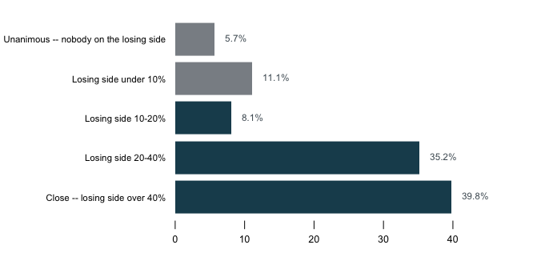

**Figure 2. Roll calls by how large the losing side was.** Horizontal bars fit this question because the record falls into five ordered bands, and the point is how much of the whole each band holds. The grey bands at the top carry almost no information about who disagrees with whom. Hovering also gives the running total down the bands: 16.8% of recorded votes are unanimous or near-unanimous.

5.7% of recorded votes are unanimous and 16.8% have a losing side under a tenth. Against that, 39.8% are genuinely close. The informative half of the record is roughly half of it, and which half you are looking at depends entirely on the question you asked. A study of contested votes and a study of everything Congress recorded are studies of two different files that happen to share a name.

## What this data cannot tell you

**Nothing here measures what was never voted on.** A bill that dies in committee, an amendment ruled out of order, a question the leadership declines to schedule: none of it appears. No analysis of this file can recover it. The agenda is set by people with an interest in the outcome, and it is invisible in exactly the way a survey’s unasked questions are invisible. This is the largest limitation of the source and the one least often stated.

The file is **researcher-assembled**, not a government publication. Poole, Rosenthal, Lewis and colleagues built it from the Journals for the early Congresses and from the votes the Clerk of the House and the Senate publish themselves for the modern ones. It is enormously convenient, meticulously done, and under no legal obligation to anybody. Its gaps, including the missing questions, are inherited along with the convenience.

This chapter also does not distinguish sincere from strategic voting, because nothing in the record can. A recorded vote is an act, not a preference, and the gap between them is where much of legislative politics lives.

Finally, “how every member voted” is not quite complete either. Members are absent, are paired (an absent member is matched with one on the other side who agrees not to vote, so that neither absence changes the result), vote “present”, or are announced without voting. Those outcomes are recorded and are not the same as a yea or a nay, and how a particular analysis treats them is a decision that this chapter has not made for you.

## Where this data appears in this book

- DW-NOMINATE and Congressional Polarization — the method that turns this record into ideology scores, and a test the most popular explanation of polarization fails.
- Ideal Points from Supreme Court Agreement — the same manufacture run on the courts’ parallel record, built from nothing but agreement.
- Counting Talk at the Supreme Court — the Court’s other record, the oral argument transcript, and six defensible answers to one counting question.
- The Age of Members of Congress — the roster half of this file, and a denominator that decides the answer.

## Sources

**Data**

- Lewis, Jeffrey B., Keith Poole, Howard Rosenthal, Adam Boche, Aaron Rudkin and Luke Sonnet. *Voteview: Congressional Roll-Call Votes Database.* `HSall_rollcalls.csv`. https://voteview.com/static/data/out/rollcalls/HSall_rollcalls.csv, from https://voteview.com/; every file the project publishes is listed at https://voteview.com/data.
- Spaeth, Harold J. et al. *The Supreme Court Database.* Washington University in St. Louis. Described here as the courts’ parallel record; read in the scdb chapter. http://scdb.wustl.edu/
- U.S. Constitution, Article I, Section 5, clause 3. https://constitution.congress.gov/browse/article-1/section-5/, or https://www.law.cornell.edu/constitution/articlei
- Legislative Reorganization Act of 1970, Pub. L. 91–510, 84 Stat. 1140. https://www.govinfo.gov/content/pkg/STATUTE-84/pdf/STATUTE-84-Pg1140.pdf; the House historian’s account of it, and of the electronic voting system it authorised, at https://history.house.gov/Historical-Highlights/1951-2000/The-Legislative-Reorganization-Act-of-1970/
- Martin, Andrew D. and Kevin M. Quinn (2002). “Dynamic Ideal Point Estimation via Markov Chain Monte Carlo for the U.S. Supreme Court, 1953–1999.” *Political Analysis* 10(2): 134–153. https://doi.org/10.1093/pan/10.2.134
- Poole, Keith T. and Howard Rosenthal (1997). *Congress: A Political-Economic History of Roll Call Voting.* Oxford University Press.
- Roberts, Jason M. (2007). “The Statistical Analysis of Roll-Call Data: A Cautionary Tale.” *Legislative Studies Quarterly* 32(3): 341–360.
- Clinton, Joshua D. (2012). “Using Roll Call Estimates to Test Models of Politics.” *Annual Review of Political Science* 15: 79–99.

**The data itself**

Every figure above is drawn from these tables. They are plain CSV, they open in a spreadsheet, and they are yours to take further.

`content.csv`, `margins.csv`, `questions.csv`, `volume.csv`

**Your turn**

None of these is answered above, and every one can be answered from the tables you just opened.

- `content.csv` gives `question_recorded_pct` by era. Find when the record starts saying what votes were about. What can you not ask about the years before that?
- `margins.csv` bands the votes by how close they were, in `band` and `pct`. Work out the share that were unanimous or nearly so. What does that do to a study of contested votes?
- `questions.csv` gives the most common questions, with `pct_of_recorded` and `pct_of_all`. Compare the two columns. Why are they so different?
- `volume.csv` counts roll calls per Congress in `house` and `senate`. Plot it. Is a rise in recorded votes a rise in disagreement, or a change in procedure?

Rebuild this data yourself, with an AI assistant

```
I want to rebuild a public dataset from its original source, without any
starting files. Please do the following and show your work.

THE SOURCE. Voteview, the congressional roll-call database. One CSV,
about 30 MB, no account or key:
https://voteview.com/static/data/out/rollcalls/HSall_rollcalls.csv
Each row is one recorded vote — one roll call — in the House or
Senate, from the 1st Congress to the present, with the yea and nay
totals and a field for the question being voted on. Hold on to what is
NOT in it: the Constitution requires a recorded vote only when a fifth
of those present demand one, so voice votes and unanimous consent —
most legislative business — leave no row here at all.

WHAT TO BUILD.
1. Roll calls per Congress, split by chamber — the volume of the
   record over time.
2. The share of roll calls whose question field is actually filled in,
   by era. This is the finding: for the first two centuries the record
   is complete about behaviour and nearly empty about content.
3. How lopsided the recorded votes are: unanimous, near-unanimous, and
   close.

CHECK YOUR WORK. The copy this book used was downloaded in August 2026.
If your rebuild matches it, you should find:
- 113,512 roll calls, Congresses 1 through 119
- 78,314 roll calls carry no question text at all — and the emptiness
  is not scattered: before the 101st Congress essentially nothing is
  recorded, after it nearly everything is
- 6,520 roll calls are unanimous, with nobody on the losing side
The file grows with every recorded vote, and the newest Congress is
still sitting; a larger final Congress means the record moved on, not
that you made an error.
```

[^1]: Article I, Section 5, clause 3: “Each House shall keep a Journal of its Proceedings,” https://www.law.cornell.edu/constitution/articlei.
[^2]: The Legislative Reorganization Act of 1970 opened the House’s amendment stage to recorded votes and authorised the electronic system, first used on 23 January 1973: https://history.house.gov/Historical-Highlights/1951-2000/The-Legislative-Reorganization-Act-of-1970/. The Act itself is Pub. L. 91–510, 84 Stat. 1140, https://www.govinfo.gov/content/pkg/STATUTE-84/pdf/STATUTE-84-Pg1140.pdf.
[^3]: Andrew D. Martin and Kevin M. Quinn, “Dynamic Ideal Point Estimation via Markov Chain Monte Carlo for the U.S. Supreme Court, 1953–1999,” *Political Analysis* 10, no. 2 (2002): 134–153, https://doi.org/10.1093/pan/10.2.134.